# In-class Exercise 4c

In this exercise, I learnt how perform multivariate analysis using a Parallel Coordinates Plot (PCP) in R

Sia Heng Guang https://www.linkedin.com/in/hengguang/ (MITB Analytics Track)https://scis.smu.edu.sg/  
2022-02-12

## Installing relevant libraries

```r
packages = c('GGally', 'parcoords', 'parallelPlot', 'tidyverse')

for (p in packages){
  if(!require(p, character.only = T)){
    install.packages(p)
  }
  library(p, character.only = T)
}
```

## Importing data

```r
wh <- read_csv("data/WHData-2018.csv")
```

## Building a PCP using ggparcoord() of GGally package

The code chunk below is used to plot a basic parallel coordinates by using ggparcoord() of GGally package.

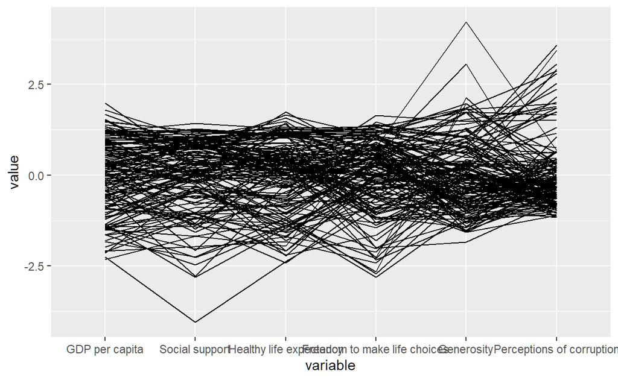

```r
ggparcoord(data = wh,
           columns = c(7:12))
```

- Underlay univariate boxplots, add title, use uniminmax scaling

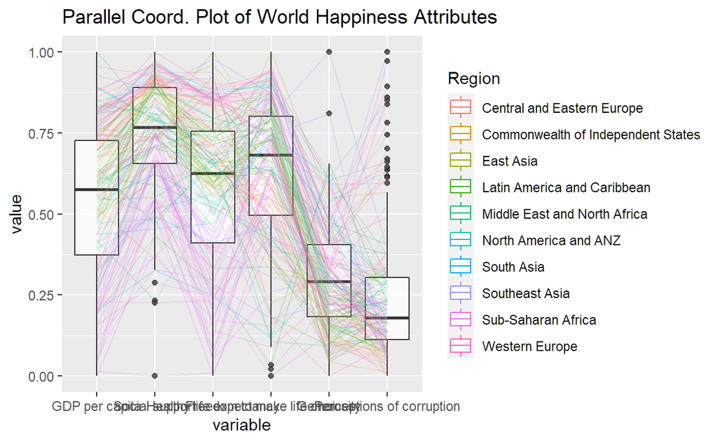

```r
ggparcoord(data = wh,
           columns = c(7:12),
           groupColumn = 2,
           scale = "uniminmax",
           alphaLines = 0.2,
           boxplot = TRUE,
           title = "Parallel Coord. Plot of World Happiness Attributes")
```

We can plot PCP with facet.

- Underlay univariate boxplots, add title, use uniminmax scaling

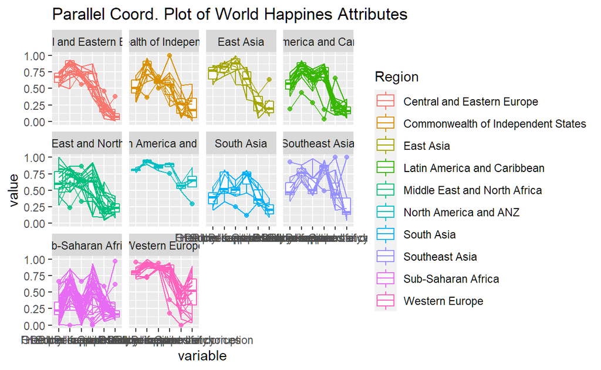

```r
ggparcoord(data = wh,
           columns = c(7:12),
           groupColumn = 2,
           scale = "uniminmax",
           boxplot = TRUE,
           title = "Parallel Coord. Plot of World Happines Attributes") +
  facet_wrap(~ Region)
```

## Building a PCP using parcoord()

parcoords is a htmlwidget for d3 parallel coordinates plot. It can plot an interactive PCP and also serves the flexibility, and robustness of htmlwidgets. We can also implement [parcoords in Shiny](https://cran.r-project.org/web/packages/parcoords/parcoords.pdf)

### Static PCP

The code below plot a parallel coordinates plot using the basic parcoords() syntax.

```r
parcoords(wh[,7:12])
```

[interactive chart not shown]

In fact, the basic syntax can only plot a static parallel coordinates plot.

### Interactive PCP

In the code chunk below, two interactivity arguments are used, they are:

- reorderable argument enables reordering of axes when it is set to TRUE or T, and
- brushMode argument provides highlighting with brushing. Three options are provided, they are: “1D-axes”, “1D-axes-multi”, or “2D-strums”.

```r
parcoords(
 wh[,7:12],
 rownames = FALSE,
 reorderable = T,
 brushMode = '1D-axes',
 width = 700,
 height = 400)
```

[interactive chart not shown]

- By setting the rownames argument to FALSE will exclude the default rawnames column.
- By using width argument to avoid horizontal scrolling.
- By using height argument to change the height of the parallel coordinates plot.

### Changing aesthetic properties

```r
parcoords(
 wh[,7:12],
 rownames = FALSE,
 alpha = 0.3,
 alphaOnBrushed = 0.2,
 reorderable = T,
 brushMode = '1D-axes',
 width = 700,
 height = 400)
```

[interactive chart not shown]

## Building a PCP using parallelPlot()

[parallelPlot](https://cran.r-project.org/web/packages/parallelPlot/) is an R package specially designed to plot a parallel coordinates plot by using ‘htmlwidgets’ package and d3.js.

The code chunk below plot an interactive parallel coordinates plot by using parallelPlot().

### Basic Plot

```r
wh <- wh %>%
  select("Happiness score", c(7:12))
parallelPlot(wh)
```

[interactive chart not shown]

### Changing the aesthetics

In the code chunk below, rotateTitle argument is used to avoid overlapping axis labels.

```r
parallelPlot(wh,
             rotateTitle = TRUE)
```

[interactive chart not shown]

One of the useful interactive feature of parallelPlot is we can click on a variable of interest, for example Happiness score, the monotonous blue colour (default) will change a blues with different intensity colour scheme will be used.

We can change the default blue colour scheme by using continousCS argument as shown in the code chunk below.

```r
parallelPlot(wh,
             continuousCS = "YlOrRd",
             rotateTitle = TRUE)
```

[interactive chart not shown]

### Combining plots

In the code chunk below, histoVisibility argument is used to plot histogram along the axis of each variables.

```r
histoVisibility <- rep(TRUE, ncol(wh))
parallelPlot(wh,
             rotateTitle = TRUE,
             histoVisibility = histoVisibility)
```

[interactive chart not shown]